# K-Nearest Neighbors

[figure not shown]

## Part 1: KNNs from Scratch

### Importing Libraries

```python
import numpy as np
import matplotlib.pyplot as plt
import seaborn as sns
import pandas as pd
import statistics
import PIL
!pip3 install idx2numpy
import idx2numpy
```

### Extracting the dataset

The MNIST dataset consists of 70,000 labeled images of handwritten digits, each of size 28 pixels by 28 pixels, yielding a total of 784 pixels per picture.

Each pixel has a single pixel-value associated with it, indicating the lightness or darkness of that pixel, with higher numbers meaning darker. This value ranges from 0-255

The dataset can be downloaded from [here](https://www.kaggle.com/datasets/hojjatk/mnist-dataset) and is also available to in your assignment directory. The four relevant files in the folder are:

- train-images-idx3-ubyte: training set images
- train-labels-idx1-ubyte: training set labels
- t10k-images-idx3-ubyte: test set images
- t10k-labels-idx1-ubyte: test set labels

The dataset has been split with 60,000 images in the train set, and the remaning 10,000 images in the test set.

```python
#Input the file paths
train_labels_path = 'mnist/train-labels.idx1-ubyte'
train_images_path = 'mnist/train-images.idx3-ubyte'
test_images_path = 'mnist/t10k-images.idx3-ubyte'
test_labels_path = 'mnist/t10k-labels.idx1-ubyte'

train_images = idx2numpy.convert_from_file(train_images_path)
train_labels = idx2numpy.convert_from_file(train_labels_path)
test_images = idx2numpy.convert_from_file(test_images_path)
test_labels = idx2numpy.convert_from_file(test_labels_path)

print("Train images shape:", train_images.shape)
print("Train labels shape:", train_labels.shape)
print("Test images shape:", test_images.shape)
print("Test labels shape:", test_labels.shape)

#TODO: Print the shape of the multidimensional array for both train and test set [1 mark]
```

```
Train images shape: (60000, 28, 28)
Train labels shape: (60000,)
Test images shape: (10000, 28, 28)
Test labels shape: (10000,)
```

```python
#TODO: Flatten the array, append the labels and print the shape again [5 mark]
#The shape of your train set should be (60000, 785), and test set should be (10000, 785)
#IMPORTANT: If your shapes are not matching, dont attempt the rest of the assignment unless you get it right.


train_images_flat = train_images.reshape(train_images.shape[0], -1)
test_images_flat = test_images.reshape(test_images.shape[0], -1)

train_data = np.column_stack((train_images_flat, train_labels))
test_data = np.column_stack((test_images_flat, test_labels))

print("Train data shape:", train_data.shape)
print("Test data shape:", test_data.shape)
```

```
Train data shape: (60000, 785)
Test data shape: (10000, 785)
```

### Visualizing and preprocessing the dataset

Now that we have a dataset to work with, we need to preprocess it further, before we pass it through our classifier. In this step, we will be seperating out the labels from the inputs, and attempt to standardize or normalize our dataset.

Note that the standardization of a variable $x$ refers to: $$ x' = \frac{x - μ}{σ} $$

where $μ$ is the mean of the variable and $σ$ is the standard deviation.

On the other hand, variable normalization usually involves scaling the data to a specific range.

```python
#TODO: Extract labels and features [2 marks]


train_x = train_data[:, :-1]
train_y = train_data[:, -1]
test_x = test_data[:, :-1]
test_y = test_data[:, -1]

print(train_x.shape)
print(train_y.shape)
print(test_x.shape)
print(test_y.shape)
```

```
(60000, 784)
(60000,)
(10000, 784)
(10000,)
```

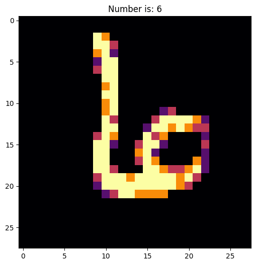

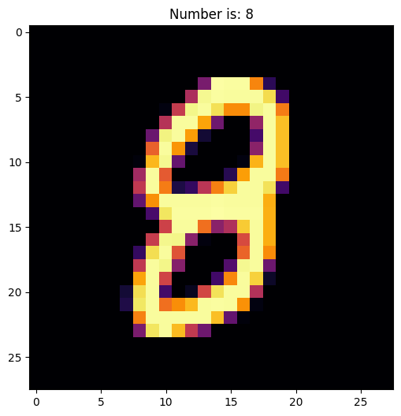

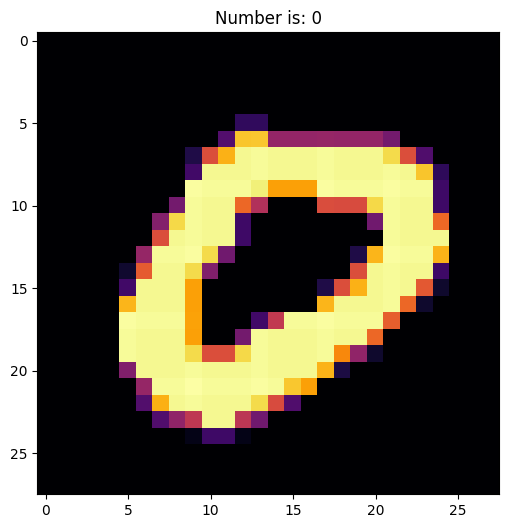

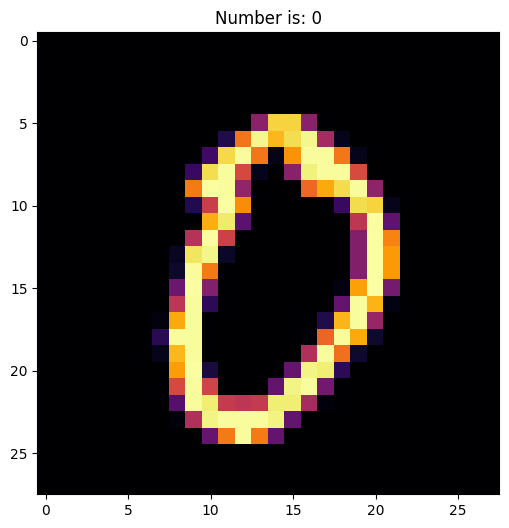

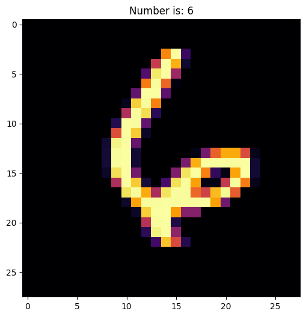

```python
#TODO: Implement a function to display image. The label should be used as a title [6 marks]
#      Randomly pick 5 rows from the training dataset and display their images

def display_image(features, label):
  '''
    Takes a 1D numpy array, reshapes to a 28x28 array and displays the image
  '''
  image = features.reshape(28,28)
  plt.figure(figsize=(6, 6))
  plt.imshow(image, cmap= 'inferno')
  plt.title("Number is: " + str(label))
  plt.show()

  return None

shuffled_indices = np.random.permutation(len(train_x))

for idx in range(5):
    rand_num = shuffled_indices[idx]
    image_data = train_x[rand_num]
    label = train_y[rand_num]
    display_image(image_data, label )
```

```python
#TODO: normalize the data so that it falls in the [0, 1] range. [2 marks]
#      Hint: the max value of each pixel is 255

def normalize(data):
  '''
    scales the data to the range [0, 1]
  '''

  return data / 255.0


normalized_train_x = normalize(train_x)
normalized_test_x = normalize(test_x)

print("Normalized train data range:", normalized_train_x.min(), normalized_train_x.max())
print("Normalized test data range:", normalized_test_x.min(), normalized_test_x.max())
```

```
Normalized train data range: 0.0 1.0
Normalized test data range: 0.0 1.0
```

A lot of the pixels do not represent the digit itself in MNIST and represent the background of the image and have values close to 0, making information less useful. SThe dataset's sparsity indicates that the majority of pixels in the majority of photos are identical (0). Since the information in the MNIST dataset is more local and specific to each image, standardising these pixels using a global mean and standard deviation could mask the information in the pixels that make up the digit itself. Since global means and standard deviations are averaged across numerous photos with different digits, they might not adequately represent the variability in digit shapes.

### Implementing k-NN Classifier

1. For a test data point, find its distance from all training instances.
2. Sort the calculated distances in ascending order based on distance values.
3. Choose k training samples with minimum distances from the test data point.
4. Return the *most frequent* class of these samples.

For values of `k` where a tie occurs, you need to break the tie by backing off to the `k-1` value. In case there is still a tie, you will continue decreasing `k` until there is a clear winner.

#### Distance functions

We will implement separate functions for the Euclidean and Manhattan distances. Formulas for both are given below.

$$ d_{\text{Euclidean}}(\vec{p},\vec{q}) = \sqrt{(p_1 - q_1)^2 + (p_2 - q_2)^2 + (p_3 - q_3)^2 + ... + (p_n - q_n)^2} $$$$ d_{\text{Manhattan}}(\vec{p},\vec{q}) = |(p_1 - q_1)| + |(p_2 - q_2)| + |(p_3 - q_3)| + ... + |(p_n - q_n)| $$

```python
from collections import Counter


class KNN:

  def __init__(self, k):
    '''
      Initializes the class
    '''

    self.k = k
    self.train_x = None
    self.train_y = None

  def euclidean_distance(self, x1, x2):

    '''
      Takes two numpy arrays and calculates the euclidean distance between them
    '''
    euclid = x2 - x1
    euclid = np.square(euclid)
    euclid = np.sum(euclid, axis =1)
    euclid = np.sqrt(euclid)
    return euclid


  def manhattan_distance(self, x1, x2):
    '''
      Takes two numpy arrays and calculates the manhattan distance between them
    '''
    manhatt = x2 - x1
    manhatt = np.abs(manhatt)
    manhatt = np.sum(manhatt, axis =1)
    return manhatt


  def fit(self, train_x, train_y):
    '''
      Stores the training dataset
    '''
    self.train_x = train_x
    self.train_y = train_y

    return None


  def get_neighbors(self, new_point, distancefunc):
    '''
      Takes a new point and returns the k nearest neighbors
      Hint: Sort the distances by their index to get the labels easily
    '''
    if distancefunc == 'manhattan_distance':
      dist = self.manhattan_distance(self.train_x, new_point)
    else:
      dist = self.euclidean_distance(self.train_x, new_point)

    neighbour_list = np.argpartition(dist,self.k)

    neighbour = neighbour_list[:self.k]

    return self.train_y[neighbour]



  def predict(self, test_x, distancefunc):
    '''
      Takes a test set and returns the predicted labels
    '''

    predicted_labels = []
    for idx in test_x:
      labels = self.get_neighbors(idx, distancefunc)
      modal_values = statistics.multimode(labels)
      predicted_labels.append(modal_values[0])

    return predicted_labels
```

### Evaluation

- We will be implementing an `evaluate` function that computes the Confusion Matrix, Accuracy, and Macro-Average F1 score of your classifier. You can use multiple helper functions to calculate the individual metrics.
- The function should take as input the predicted labels and the true labels. This will be built in steps: its easier to create a Confusion Matrix, then calculate things like the Precision, Recall and F1 from it.
- We will also implement a function that displays our confusion matrix as a heatmap annotated with the data values.

```python
def accuracy(predicted_labels, true_labels):
  '''
    Takes the predicted labels and the true labels and returns the accuracy
  '''
  accuracy_value = predicted_labels == true_labels
  accuracy_value = np.sum(accuracy_value)
  accuracy_value = accuracy_value/len(true_labels)

  return accuracy_value




def make_confusion_matrix(predicted_labels, true_labels):
    '''
    Takes the predicted labels and the true labels and returns the confusion matrix
    '''
    unique_classes = np.unique(true_labels)
    matrix = []

    for class_label in unique_classes:
        class_count = [0] * len(unique_classes)

        for index in range(len(true_labels)):
            true_label = true_labels[index]
            pred_label = predicted_labels[index]

            if true_label == class_label:
                if pred_label == class_label:
                    class_count[class_label] += 1
                else:
                    class_count[pred_label] += 1

        matrix.append(class_count)

    return matrix



def make_heat_map(confusion_matrix, title):
  '''
    Takes the confusion matrix and plots it as a heatmap
  '''
  plt.figure(figsize=(8, 8))
  sns.heatmap(confusion_matrix, annot=True, fmt="d", cmap="Reds")
  plt.title(title)
  plt.xlabel("Predicted Label")
  plt.ylabel("True Label")
  plt.show()

  return None


def precision(confusion_matrix, class_label):
    '''
    Takes the confusion matrix and a label and returns the precision
    '''
    gold_label = confusion_matrix[class_label][class_label]
    predicted_label = np.sum(confusion_matrix[class_label])

    if predicted_label == 0:
        return 0

    precision_value = gold_label / predicted_label
    return precision_value


def recall(confusion_matrix, class_label):
    '''
    Takes the confusion matrix and a label and returns the recall
    '''
    gold_label = confusion_matrix[class_label][class_label]
    predicted_positives = np.sum(confusion_matrix[class_label])

    if predicted_positives == 0:
        return 0

    recall_value = gold_label / predicted_positives
    return recall_value


def f1_score(precision, recall):
  '''
    Takes the precision and recall and returns the f1 score
  '''
  score_value = (2*precision*recall)/(precision+recall)

  return score_value


def macro_average_f1(confusion_matrix):
  '''
    Calculates the macro-average F1 score from a provided confusion matrix, over all classes
  '''
  num_classes = len(confusion_matrix)
  f1_scores = []

  for class_label in range(num_classes):

      class_precision = precision(confusion_matrix, class_label)
      class_recall = recall(confusion_matrix, class_label)

      if (class_precision + class_recall) == 0:
          class_f1 = 0
      else:
          class_f1 = f1_score(class_precision,class_recall)

      f1_scores.append(class_f1)

  return np.mean(f1_scores)


def evaluate(predicted_labels, true_labels):
  '''
    Displays and returns a nicely formatted report with accuracy, macro-average f1 score, and confusion matrix
  '''
  confusion_matrix = make_confusion_matrix(predicted_labels, true_labels)
  accuracy_value = accuracy(predicted_labels, true_labels)
  macro_f1_value = macro_average_f1(confusion_matrix)

  report = f"Confusion Matrix:\n{confusion_matrix} \nAccuracy: {accuracy_value * 100:.2f}%\nMacro-Average F1 Score: {macro_f1_value:.2f}\n"

  return confusion_matrix, report
```

```python
def k_fold_split(num_folds, cv_no, train_x, train_y):
    '''
    Creates the train and test splits based off the value of k

    Parameters
    ----------
    num_folds : int
        Number of folds
    cv_no : int
        The current fold number
    train_x : nparray
        The features
    train_y : nparray
        The labels
    '''

    size_of_fold = len(train_x) // num_folds
    start_index = size_of_fold * cv_no
    end_index = start_index + size_of_fold

    X_fold_start = train_x[:start_index]
    X_fold_end = train_x[end_index:]

    x_folds_list = np.concatenate((X_fold_start, X_fold_end), axis=0)

    Y_fold_start = train_y[:start_index]
    Y_fold_end = train_y[end_index:]

    y_folds_list = np.concatenate((Y_fold_start, Y_fold_end), axis=0)

    X_validate = train_x[start_index:end_index]
    Y_validate = train_y[start_index:end_index]

    return x_folds_list, y_folds_list, X_validate, Y_validate



def k_fold_cross_validation(num_folds, k, train_x, train_y, distanceFunction):
    """
    Returns the predictions for all the data points in the dataset using k-fold cross validation

    num_folds: int
      Number of folds
    k: int
      Number of neighbours to consider (hyperparameter)
    train_x : nparray
        The features
    train_y : nparray
        The labels
    distanceFunction : str
        Distance metric specified (manhattan / euclidean)
    """

    actual_validation_labels = []
    predicted_validation_labels = []

    model = KNN(k) #settinh model to knn

    for idx in range(num_folds):

      train_x_fold, train_y_fold, validation_x, validation_y = k_fold_split(num_folds, idx, train_x, train_y)

      model.fit(train_x_fold, train_y_fold) #fitting model to training data

      predicted_y_fold = model.predict(validation_x, distanceFunction) #using predict function to get predicted labels (y)
      actual_validation_labels.append(validation_y)
      predicted_validation_labels.append(predicted_y_fold)

    return actual_validation_labels, predicted_validation_labels
```

### k-fold Cross Validation

[figure not shown]

Now with the basics done, we move on to the next step: k-fold Cross Validation. This is a more robust way of evaluating your model since it uses all the data for training and testing (effectively giving you `k` chances to verify the generalizability of your model).

In Cross Validation, you divide the dataset into `k` parts. `k-1` parts will be used for training and `1` part will be used for validation. You will repeat this process `k` times, each time using a different part for validation. We will then average the results of each fold to get the final result. Take a look at the image above for a better understanding.

Now run your cross-validation function on the training data using `5-fold cross validation` for the values of `k = [1, 2, 3, 4, 5]`.

Do this for both the Euclidean distance and the Manhattan distance for each value of `k`.

Also run your evaluation function for each value of `k` (for both distance metrics) and print out the classification accuracy and F1 score.

**Note: Save your evaluation stats for plotting later**

```python
accuracy_list_euclidean = []
f1_list_euclidean = []
accuracy_list_manhattan = []
f1_list_manhattan = []
```

```python
def evaluate_distance_metrics(k_values, data_x, data_y, distance_types, accuracy_lists, f1_lists):
    for k in k_values:
        for i in range(len(distance_types)):
            distance_type = distance_types[i]
            accuracy_list = accuracy_lists[i]
            f1_list = f1_lists[i]

            sum_accuracy = 0
            sum_f1 = 0

            actual_Yvalidate, predicted_Yvalidate = k_fold_cross_validation(5, k, data_x, data_y, distance_type)

            accuracy_scores = []
            f1_scores = []

            for j in range(len(actual_Yvalidate)):
                acc = accuracy(predicted_Yvalidate[j], actual_Yvalidate[j])
                macro_f1 = macro_average_f1(make_confusion_matrix(predicted_Yvalidate[j], actual_Yvalidate[j]))

                accuracy_scores.append(acc)
                f1_scores.append(macro_f1)

                print(f'For {distance_type}, accuracy: {acc}, macro-average F1: {macro_f1}')

            sum_accuracy = sum(accuracy_scores)
            sum_f1 = sum(f1_scores)

            accuracy_list.append(sum_accuracy/ 5)
            f1_list.append(sum_f1/ 5)

k_values = [1, 2, 3, 4, 5]
data_x = normalized_train_x[0:14000]
data_y = train_y[0:14000]
distance_types = ['euclidean_distance', 'manhattan_distance']
accuracy_lists = [accuracy_list_euclidean, accuracy_list_manhattan]
f1_lists = [f1_list_euclidean, f1_list_manhattan]

evaluate_distance_metrics(k_values, data_x, data_y, distance_types, accuracy_lists, f1_lists)
```

```
For euclidean_distance, accuracy: 0.9485714285714286, macro-average F1: 0.9475394986014075
For euclidean_distance, accuracy: 0.9496428571428571, macro-average F1: 0.9485531412068944
For euclidean_distance, accuracy: 0.9417857142857143, macro-average F1: 0.940627165387245
For euclidean_distance, accuracy: 0.9442857142857143, macro-average F1: 0.9429220726087009
For euclidean_distance, accuracy: 0.9428571428571428, macro-average F1: 0.9425854409209068
For manhattan_distance, accuracy: 0.9403571428571429, macro-average F1: 0.9390464670156963
For manhattan_distance, accuracy: 0.9417857142857143, macro-average F1: 0.940633112850336
For manhattan_distance, accuracy: 0.9339285714285714, macro-average F1: 0.9326720057498527
For manhattan_distance, accuracy: 0.9346428571428571, macro-average F1: 0.9329002019449218
For manhattan_distance, accuracy: 0.9335714285714286, macro-average F1: 0.9334000891326856
For euclidean_distance, accuracy: 0.9485714285714286, macro-average F1: 0.9475394986014075
For euclidean_distance, accuracy: 0.9496428571428571, macro-average F1: 0.9485531412068944
For euclidean_distance, accuracy: 0.9417857142857143, macro-average F1: 0.940627165387245
For euclidean_distance, accuracy: 0.9442857142857143, macro-average F1: 0.9429220726087009
For euclidean_distance, accuracy: 0.9428571428571428, macro-average F1: 0.9425854409209068
For manhattan_distance, accuracy: 0.9403571428571429, macro-average F1: 0.9390464670156963
For manhattan_distance, accuracy: 0.9417857142857143, macro-average F1: 0.940633112850336
For manhattan_distance, accuracy: 0.9339285714285714, macro-average F1: 0.9326720057498527
For manhattan_distance, accuracy: 0.9346428571428571, macro-average F1: 0.9329002019449218
For manhattan_distance, accuracy: 0.9335714285714286, macro-average F1: 0.9334000891326856
For euclidean_distance, accuracy: 0.9517857142857142, macro-average F1: 0.9508870551139601
For euclidean_distance, accuracy: 0.9521428571428572, macro-average F1: 0.9510616774997626
For euclidean_distance, accuracy: 0.9460714285714286, macro-average F1: 0.944855574661595
For euclidean_distance, accuracy: 0.9496428571428571, macro-average F1: 0.9484649067013249
For euclidean_distance, accuracy: 0.9432142857142857, macro-average F1: 0.9426797800610686
For manhattan_distance, accuracy: 0.9464285714285714, macro-average F1: 0.9454265116365986
For manhattan_distance, accuracy: 0.945, macro-average F1: 0.9439596493891409
For manhattan_distance, accuracy: 0.9375, macro-average F1: 0.9363355294123318
For manhattan_distance, accuracy: 0.9385714285714286, macro-average F1: 0.9365616683990904
For manhattan_distance, accuracy: 0.9314285714285714, macro-average F1: 0.930771092874447
For euclidean_distance, accuracy: 0.9510714285714286, macro-average F1: 0.9501603936148764
For euclidean_distance, accuracy: 0.95, macro-average F1: 0.948992657700239
For euclidean_distance, accuracy: 0.945, macro-average F1: 0.9436277020205693
For euclidean_distance, accuracy: 0.9492857142857143, macro-average F1: 0.9480812820958343
For euclidean_distance, accuracy: 0.9410714285714286, macro-average F1: 0.9405295507784492
For manhattan_distance, accuracy: 0.9439285714285715, macro-average F1: 0.9431520994277681
For manhattan_distance, accuracy: 0.9435714285714286, macro-average F1: 0.9424508181612788
For manhattan_distance, accuracy: 0.9371428571428572, macro-average F1: 0.9357257348206343
For manhattan_distance, accuracy: 0.9392857142857143, macro-average F1: 0.9373862312175699
For manhattan_distance, accuracy: 0.9310714285714285, macro-average F1: 0.9305373001151956
For euclidean_distance, accuracy: 0.9517857142857142, macro-average F1: 0.9509186652979261
For euclidean_distance, accuracy: 0.9517857142857142, macro-average F1: 0.9507910836448253
For euclidean_distance, accuracy: 0.9478571428571428, macro-average F1: 0.9463733634582017
For euclidean_distance, accuracy: 0.9482142857142857, macro-average F1: 0.9468008761184853
For euclidean_distance, accuracy: 0.9425, macro-average F1: 0.9418976114850741
For manhattan_distance, accuracy: 0.9428571428571428, macro-average F1: 0.9418553977568536
For manhattan_distance, accuracy: 0.9425, macro-average F1: 0.9411849595306693
For manhattan_distance, accuracy: 0.9392857142857143, macro-average F1: 0.9379524434094251
For manhattan_distance, accuracy: 0.9378571428571428, macro-average F1: 0.9357437929896261
For manhattan_distance, accuracy: 0.9325, macro-average F1: 0.9320233310166754
```

```python
print("Euclidean Distance:")
print(f"Average accuracy for each fold: {[float(x) for x in accuracy_list_euclidean]}")

print("\nManhattan Distance:")
print(f"Average accuracy for each fold: {[float(x) for x in accuracy_list_manhattan]}")
```

```
Euclidean Distance:
Average accuracy for each fold: [0.9454285714285715, 0.9454285714285715, 0.9485714285714286, 0.9472857142857143, 0.9484285714285715]

Manhattan Distance:
Average accuracy for each fold: [0.9368571428571428, 0.9368571428571428, 0.9397857142857143, 0.9390000000000001, 0.9389999999999998]
```

Next, we present the results as a graph with `k` values on the x-axis and classification accuracy on the y-axis.

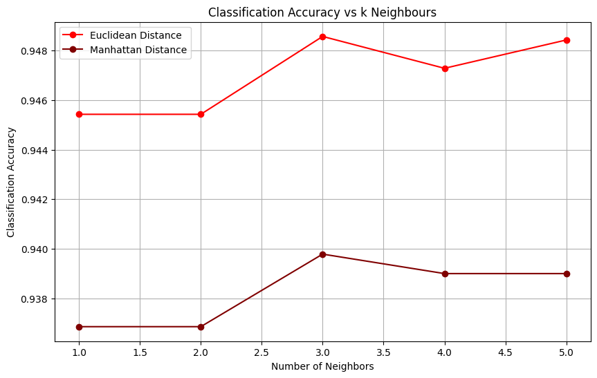

```python
#TODO: Plot a graph with k values on the x-axis and classification accuracy on the y-axis (both distances on one plot).
plt.figure(figsize=(10, 6))
plt.plot(k_values, accuracy_list_euclidean, marker='o', label='Euclidean Distance', color='red')
plt.plot(k_values, accuracy_list_manhattan, marker='o', label='Manhattan Distance', color='maroon')

plt.title('Classification Accuracy vs k Neighbours')
plt.xlabel('Number of Neighbors')
plt.ylabel('Classification Accuracy')
plt.legend()
plt.grid(True)
plt.show()
```

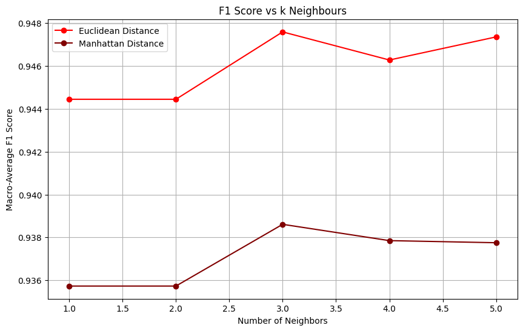

```python
plt.figure(figsize=(10, 6))
plt.plot(k_values, f1_list_euclidean, marker='o', label='Euclidean Distance', color='red')
plt.plot(k_values, f1_list_manhattan, marker='o', label='Manhattan Distance', color='maroon')

plt.title('F1 Score vs k Neighbours')
plt.xlabel('Number of Neighbors')
plt.ylabel('Macro-Average F1 Score')
plt.legend()
plt.grid(True)

plt.show()
```

### Prediction

Finally, use the best value of `k` for both distance metrics and run it on the test dataset.

Diplayed are the confusion matrix, classification accuracy and F1 score.

```python
best_k = k_values[np.argmax(accuracy_list_euclidean)]
model = KNN(best_k)
model.fit(normalized_train_x, train_y)
predicted_value = model.predict(normalized_test_x,'euclidean_distance')
```

```
Confusion Matrix:
[[974, 1, 1, 0, 0, 1, 2, 1, 0, 0], [0, 1133, 2, 0, 0, 0, 0, 0, 0, 0], [10, 7, 995, 2, 0, 0, 1, 14, 2, 1], [0, 1, 4, 976, 1, 14, 1, 7, 3, 3], [1, 4, 0, 0, 949, 0, 4, 4, 0, 20], [5, 0, 0, 12, 2, 859, 5, 1, 4, 4], [4, 3, 0, 0, 4, 3, 944, 0, 0, 0], [0, 20, 5, 0, 1, 0, 0, 992, 0, 10], [7, 0, 3, 14, 7, 10…
Accuracy: 97.12%
Macro-Average F1 Score: 0.97

[974, 1, 1, 0, 0, 1, 2, 1, 0, 0]
[0, 1133, 2, 0, 0, 0, 0, 0, 0, 0]
[10, 7, 995, 2, 0, 0, 1, 14, 2, 1]
[0, 1, 4, 976, 1, 14, 1, 7, 3, 3]
[1, 4, 0, 0, 949, 0, 4, 4, 0, 20]
[5, 0, 0, 12, 2, 859, 5, 1, 4, 4]
[4, 3, 0, 0, 4, 3, 944, 0, 0, 0]
[0, 20, 5, 0, 1, 0, 0, 992, 0, 10]
[7, 0, 3, 14, 7, 10, 3, 4, 921, 5]
[3, 4, 2, 6, 9, 5, 1, 8, 2, 969]
```

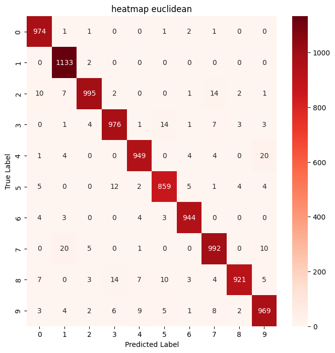

```python
confidence, score = evaluate(predicted_value, test_y)
print(score)
for i in range(len(confidence)):
    print(confidence[i])
make_heat_map(make_confusion_matrix(predicted_value, test_y), 'heatmap euclidean')
```

```python
best_k = k_values[np.argmax(f1_list_manhattan)]
model = KNN(best_k)
model.fit(normalized_train_x, train_y)
predicted_value = model.predict(normalized_test_x,'manhattan_distance')
evaluate(predicted_value, test_y)
```

```
([[974, 1, 1, 0, 0, 1, 2, 1, 0, 0],
  [0, 1134, 1, 0, 0, 0, 0, 0, 0, 0],
  [11, 12, 982, 3, 1, 0, 1, 18, 4, 0],
  [1, 3, 4, 970, 1, 17, 0, 9, 3, 2],
  [0, 13, 0, 0, 934, 0, 7, 4, 0, 24],
  [5, 0, 0, 9, 2, 858, 7, 1, 3, 7],
  [6, 3, 0, 0, 4, 3, 942, 0, 0, 0],
  [0, 25, 4, 0, 2, 0, 0, 988, 0, 9],
  [9, 3, 5, 18, 6, 15, 4, 6, 901, 7],
  [2, 7, 1, 6, 10, 4, 1, 19, 2, 957]],
 'Confusion Matrix:\n[[974, 1, 1, 0, 0, 1, 2, 1, 0, 0], [0, 1134, 1, 0, 0, 0, 0, 0, 0, 0], [11, 12, 982, 3, 1, 0, 1, 18, 4, 0], [1, 3, 4, 970, 1, 17, 0, 9, 3, 2], [0, 13, 0, 0, 934, 0, 7, 4, 0, 24], [5, 0, 0, 9, 2, 858, 7, 1, 3, 7], [6, 3, 0, 0, 4, 3, 942, 0, 0, 0], [0, 25, 4, 0, 2, 0, 0, 988, 0, 9]…
```

```
Confusion Matrix:
[[974, 1, 1, 0, 0, 1, 2, 1, 0, 0], [0, 1134, 1, 0, 0, 0, 0, 0, 0, 0], [11, 12, 982, 3, 1, 0, 1, 18, 4, 0], [1, 3, 4, 970, 1, 17, 0, 9, 3, 2], [0, 13, 0, 0, 934, 0, 7, 4, 0, 24], [5, 0, 0, 9, 2, 858, 7, 1, 3, 7], [6, 3, 0, 0, 4, 3, 942, 0, 0, 0], [0, 25, 4, 0, 2, 0, 0, 988, 0, 9], [9, 3, 5, 18, 6, 15…
Accuracy: 96.40%
Macro-Average F1 Score: 0.96

[974, 1, 1, 0, 0, 1, 2, 1, 0, 0]
[0, 1134, 1, 0, 0, 0, 0, 0, 0, 0]
[11, 12, 982, 3, 1, 0, 1, 18, 4, 0]
[1, 3, 4, 970, 1, 17, 0, 9, 3, 2]
[0, 13, 0, 0, 934, 0, 7, 4, 0, 24]
[5, 0, 0, 9, 2, 858, 7, 1, 3, 7]
[6, 3, 0, 0, 4, 3, 942, 0, 0, 0]
[0, 25, 4, 0, 2, 0, 0, 988, 0, 9]
[9, 3, 5, 18, 6, 15, 4, 6, 901, 7]
[2, 7, 1, 6, 10, 4, 1, 19, 2, 957]
```

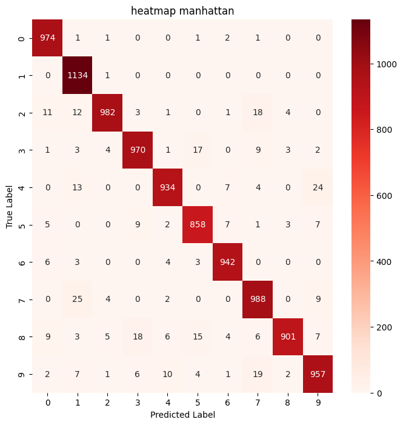

```python
confidence, score = evaluate(predicted_value, test_y)
print(score)
for i in range(len(confidence)):
    print(confidence[i])
make_heat_map(make_confusion_matrix(predicted_value, test_y), 'heatmap manhattan')
```

## Part 2: KNN using Scikit-Learn

- Using the best value of `k` from part 1 for both manhattan and euclidean distance.

```python
!pip install scikit-learn==1.4.2
from sklearn.neighbors import KNeighborsClassifier
from sklearn.metrics import accuracy_score
from sklearn.metrics import classification_report
from sklearn.metrics import confusion_matrix
```

```
zsh:1: command not found: pip
```

```
Euclidean Distance - Accuracy: 0.97, F1 Score: 0.97
Confusion Matrix (Euclidean):
[[ 974    1    1    0    0    1    2    1    0    0]
 [   0 1133    2    0    0    0    0    0    0    0]
 [  10    9  996    2    0    0    0   13    2    0]
 [   0    2    4  976    1   13    1    7    3    3]
 [   1    6    0    0  950    0    4    2    0   19]
 [   6    1    0   11    2  859    5    1    3    4]
 [   5    3    0    0    3    3  944    0    0    0]
 [   0   21    5    0    1    0    0  991    0   10]
 [   8    2    4   16    8   11    3    4  914    4]
 [   4    5    2    8    9    2    1    8    2  968]]
```

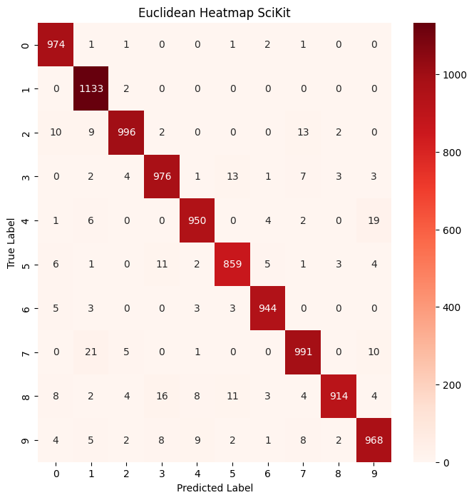

```python
best_k_euclidean = k_values[np.argmax(accuracy_list_euclidean)]

knn_euclidean = KNeighborsClassifier(n_neighbors=best_k_euclidean, metric='euclidean')
knn_euclidean.fit(normalized_train_x, train_y)

predicted_labels_euclidean = knn_euclidean.predict(normalized_test_x)
accuracy_euclidean = accuracy_score(test_y, predicted_labels_euclidean)

report_euclidean = classification_report(test_y, predicted_labels_euclidean, output_dict=True)
macro_f1_score_euclidean = report_euclidean['macro avg']['f1-score']
confusion_matrix_euclidean = confusion_matrix(test_y, predicted_labels_euclidean)

print(f"Euclidean Distance - Accuracy: {accuracy_euclidean:.2f}, F1 Score: {macro_f1_score_euclidean:.2f}")
print("Confusion Matrix (Euclidean):")
print(confusion_matrix_euclidean)

make_heat_map(confusion_matrix_euclidean, 'Euclidean Heatmap SciKit')
```

```
Manhattan Distance - Accuracy: 0.96, F1 Score: 0.96
Confusion Matrix (Manhattan):
[[ 974    1    1    0    0    1    2    1    0    0]
 [   0 1134    1    0    0    0    0    0    0    0]
 [  11   16  979    3    1    0    1   17    4    0]
 [   1    3    4  974    1   14    0    9    2    2]
 [   1   13    0    0  934    0    6    4    0   24]
 [   5    2    0   10    3  859    5    1    1    6]
 [   6    3    0    0    4    3  942    0    0    0]
 [   0   25    4    0    2    0    0  988    0    9]
 [  11    4    6   20    8   17    4    5  895    4]
 [   3    7    2    9   10    3    1   18    2  954]]
```

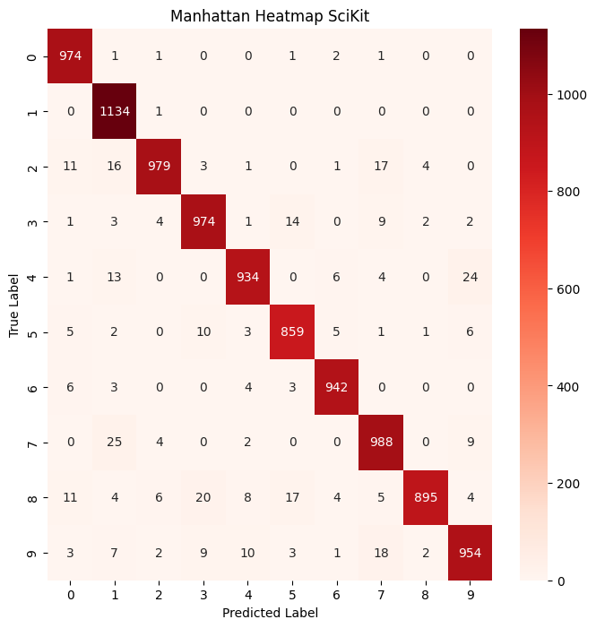

```python
best_k_manhattan = k_values[np.argmax(accuracy_list_manhattan)]

knn_manhattan = KNeighborsClassifier(n_neighbors=best_k_manhattan, metric='manhattan')
knn_manhattan.fit(normalized_train_x, train_y)

predicted_labels_manhattan = knn_manhattan.predict(normalized_test_x)
accuracy_manhattan = accuracy_score(test_y, predicted_labels_manhattan)

report_manhattan = classification_report(test_y, predicted_labels_manhattan, output_dict=True)
macro_f1_score_manhattan = report_manhattan['macro avg']['f1-score']
confusion_matrix_manhattan = confusion_matrix(test_y, predicted_labels_manhattan)

print(f"Manhattan Distance - Accuracy: {accuracy_manhattan:.2f}, F1 Score: {macro_f1_score_manhattan:.2f}")
print("Confusion Matrix (Manhattan):")
print(confusion_matrix_manhattan)

make_heat_map(confusion_matrix_manhattan, 'Manhattan Heatmap SciKit')
```

## Radius nearest neighbors

[figure not shown]

Radius Neighbors Classifier is an extension to the k-nearest neighbors algorithm that makes predictions using all examples in the radius of a new example rather than the k-closest neighbors. Read more about this neighbor-based classifier [here](https://machinelearningmastery.com/radius-neighbors-classifier-algorithm-with-python/#:~:text=Radius%20Neighbors%20Classifier%20is%20a,than%20the%20k%2Dclosest%20neighbors.).

The Radius Neighbors Classifier is similar to KNN in respect that its training involves storing the entire training dataset. However, instead of basing decisions on k-nearest neighbors, the Radius Neighbors Classifier locates all examples in the training dataset that are within a given radius of the new example to make a prediction.

For this part, we will be using the [Breast Cancer Dataset](https://www.kaggle.com/datasets/yasserh/breast-cancer-dataset).

### Task 1: Data Loading and Preprocessing

The breast cancer dataset comprises of 569 rows and 32 columns. Your task is to design a r-NN classifier that is able to classify breast tumors into malignant (cancerous) or benign (non cancerous).

```python
cancer_df = pd.read_csv('breast-cancer.csv')
print(cancer_df.shape)
print(cancer_df.head())
```

```
(569, 32)
         id diagnosis  radius_mean  texture_mean  perimeter_mean  area_mean  \
0    842302         M        17.99         10.38          122.80     1001.0
1    842517         M        20.57         17.77          132.90     1326.0
2  84300903         M        19.69         21.25          130.00     1203.0
3  84348301         M        11.42         20.38           77.58      386.1
4  84358402         M        20.29         14.34          135.10     1297.0

   smoothness_mean  compactness_mean  concavity_mean  concave points_mean  \
0          0.11840           0.27760          0.3001              0.14710
1          0.08474           0.07864          0.0869              0.07017
2          0.10960           0.15990          0.1974              0.12790
3          0.14250           0.28390          0.2414              0.10520
4          0.10030           0.13280          0.1980              0.10430

```

[output cut: 22 more lines]

```python
cancer_df.drop('id', axis = 1, inplace = True)


cancer_df['diagnosis'] = cancer_df['diagnosis'].map({'M': 1, 'B': 0})
```

```python
train_dataset = cancer_df.sample(frac=0.8, random_state=42)
test_dataset = cancer_df.drop(train_dataset.index)


train_x = train_dataset.drop('diagnosis', axis=1)
train_y = train_dataset['diagnosis']
test_x = test_dataset.drop('diagnosis', axis=1)
test_y = test_dataset['diagnosis']


print(train_x.shape)
print(train_y.shape)
print(test_x.shape)
print(test_y.shape)
```

```
(455, 30)
(455,)
(114, 30)
(114,)
```

```python
train_x = np.array(train_x)
train_y = np.array(train_y)
test_x = np.array(test_x)
test_y = np.array(test_y)

print("train_x shape:", train_x.shape)
print("train_y shape:", train_y.shape)
print("test_x shape:", test_x.shape)
print("test_y shape:", test_y.shape)




mean = np.mean(train_x, axis=0)
sd = np.std(train_x, axis=0)
normalized_train_x = (train_x-mean)/sd
normalized_test_x = (test_x-mean)/sd
```

```
train_x shape: (455, 30)
train_y shape: (455,)
test_x shape: (114, 30)
test_y shape: (114,)
```

### Task 2: Implementing r-NN Classifier

- For a test data point, find its distance from all training instances.
- Sort the calculated distances in ascending order based on distance values.
- Choose all of the training examples that are within the radius `r`
- Return the most frequent class of these samples.

**Note:** Sometimes for the radius `r`, it is possible that you will not have any training examples in the given radius for some test data points. In this case, simply return the **majority class** of the dataset.

On the other hand, if there is a tie, you can use a similar strategy as before. Remove the furthest training example from your choosen neighbors to take a vote.

```python
class RNN:

  def __init__(self, r):
    #DO NOT EDIT !#
    '''
      Initializes the class
    '''

    self.r = r
    self.train_x = None
    self.train_y = None

  def euclidean_distance(self, x1, x2):

    '''
      Takes two numpy arrays and calculates the euclidean distance between them
    '''
    euclid = x2 - x1
    euclid = np.square(euclid)
    euclid = np.sum(euclid, axis =1)
    euclid = np.sqrt(euclid)
    return euclid


  def manhattan_distance(self, x1, x2):

    '''
      Takes two numpy arrays and calculates the manhattan distance between them
    '''
    manhatt = x2 - x1
    manhatt = np.abs(manhatt)
    manhatt = np.sum(manhatt, axis =1)
    return manhatt

  def fit(self, train_x, train_y):
    '''
      Stores the training dataset
    '''
    self.train_x = train_x
    self.train_y = train_y

  def get_neighbors(self, new_point, distancefunc):
    '''
      Takes a new point and returns the nearest neighbors within the radius r
      Hint: Sort the distances by their index to get the labels easily
    '''
    distances = []

    if distancefunc == 'manhattan_distance':
      dist = self.manhattan_distance(self.train_x, new_point)
    else:
      dist = self.euclidean_distance(self.train_x, new_point)

    for d in range(len(dist)):
      if dist[d] < self.r:  # Check if the distance is less than the specified radius
          distances.append(d)

    neighbours = self.train_y[distances]

    return neighbours


  def predict(self, test_x, distancefunc):
    '''
      Takes a test set and returns the predicted labels
    '''
    predicted_labels = []

    modal_class = statistics.multimode(self.train_y)
    largest = modal_class[0]

    for idx in test_x:
      neighbour_list = self.get_neighbors(idx, distancefunc)

      majority_class = statistics.multimode(neighbour_list)

      if (len(majority_class) > 0):
        predicted_labels.append(majority_class[0])
      else:
        predicted_labels.append(largest)

    return predicted_labels
```

### Task 3: k-fold Cross Validation

In this part, for **euclidean distance**, uniformally sample **20** different values of `r` from the range `3.5-5.5`. Use these values of `r` for 5-fold cross validation using the functions you implemented in part 1.

For **manhattan distance** uniformally sample **20** different values of `r` from the range `15.5-17.5`. Use these values of `r` for 5-fold cross validation using the functions you implemented in part 1.

Again, for each `r`, conduct the cross validation for both distances and report accuracy and macro-f1 score for each `r` and distance. You can use sklearn evaluation metrics to report the results

```python
def k_fold_cross_validation_rnn(num_folds, r, train_x, train_y, distanceFunction):
  """
    Returns the predictions for all the data points in the dataset using k-fold cross validation

    num_folds: int
      Number of folds
    r: float
      Radius of neighbours to consider (hyperparameter)
    train_x: np array
      The dataset features to be used
    test_x: np array
      The dataset labels to be used
    distancefunc: str
      The distance function to be used
    """
  actual_validation_labels = []
  predicted_validation_labels = []

  model = RNN(r) #settinh model to knn

  for idx in range(num_folds):

    train_x_fold, train_y_fold, validation_x, validation_y = k_fold_split(num_folds, idx, train_x, train_y)

    model.fit(train_x_fold, train_y_fold) #fitting model to training data

    predicted_y_fold = model.predict(validation_x, distanceFunction) #using predict function to get predicted labels (y)
    actual_validation_labels.append(validation_y)
    predicted_validation_labels.append(predicted_y_fold)

  return actual_validation_labels, predicted_validation_labels
```

```python
#list for storing results
accuracy_list_euclidean = []
f1_list_euclidean = []
accuracy_list_manhattan = []
f1_list_manhattan = []

r_euclidean = np.linspace(3.5, 5.5, 20)
r_manhattan =  np.linspace(15.5, 17.5, 20)
```

```python
def perform_cross_validation(distance_metric, r_values, accuracy_list, f1_list):
    for radius in r_values:
        actual_labels, predicted_labels = k_fold_cross_validation_rnn(5, radius, normalized_train_x, train_y, distance_metric)

        accuracy_scores = []
        for i in range(len(actual_labels)):
            acc = accuracy(predicted_labels[i], actual_labels[i])
            accuracy_scores.append(acc)

        f1_scores = []
        for i in range(len(actual_labels)):
            cm = make_confusion_matrix(predicted_labels[i], actual_labels[i])
            f1 = macro_average_f1(cm)
            f1_scores.append(f1)

        accuracy_list.append(sum(accuracy_scores) / len(accuracy_scores))
        f1_list.append(sum(f1_scores) / len(f1_scores))

accuracy_list_euclidean, f1_list_euclidean = [], []
accuracy_list_manhattan, f1_list_manhattan = [], []

perform_cross_validation('euclidean_distance', r_euclidean, accuracy_list_euclidean, f1_list_euclidean)

perform_cross_validation('manhattan_distance', r_manhattan, accuracy_list_manhattan, f1_list_manhattan)
```

```python
print("Euclidean Distance:")
print(f"Average accuracy for each fold: {[float(x) for x in accuracy_list_euclidean]}")

print("\nManhattan Distance:")
print(f"Average accuracy for each fold: {[float(x) for x in accuracy_list_manhattan]}")
```

```
Euclidean Distance:
Average accuracy for each fold: [0.8659340659340661, 0.8747252747252748, 0.8791208791208792, 0.8857142857142858, 0.8967032967032967, 0.9054945054945055, 0.9054945054945055, 0.9032967032967033, 0.9120879120879122, 0.9098901098901099, 0.9054945054945055, 0.9032967032967033, 0.9054945054945055, 0.90329…

Manhattan Distance:
Average accuracy for each fold: [0.8813186813186814, 0.8857142857142858, 0.887912087912088, 0.8901098901098902, 0.8901098901098902, 0.8923076923076924, 0.8923076923076924, 0.8923076923076924, 0.8923076923076924, 0.8945054945054945, 0.8923076923076924, 0.8923076923076924, 0.8901098901098902, 0.894505…
```

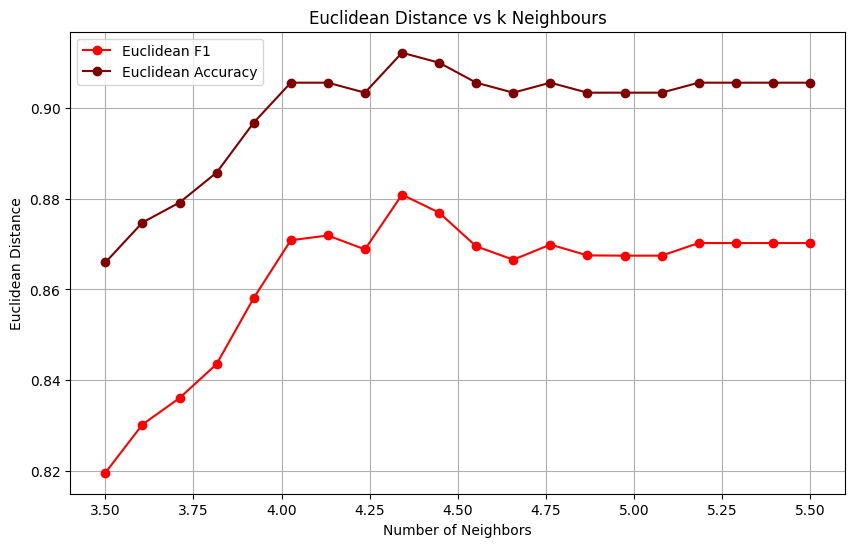

```python
plt.figure(figsize=(10, 6))
plt.plot(r_euclidean, f1_list_euclidean, marker='o', label='Euclidean F1', color='red')
plt.plot(r_euclidean, accuracy_list_euclidean, marker='o', label='Euclidean Accuracy', color='maroon')

plt.title('Euclidean Distance vs k Neighbours')
plt.xlabel('Number of Neighbors')
plt.ylabel('Euclidean Distance')
plt.legend()
plt.grid(True)

plt.show()
```

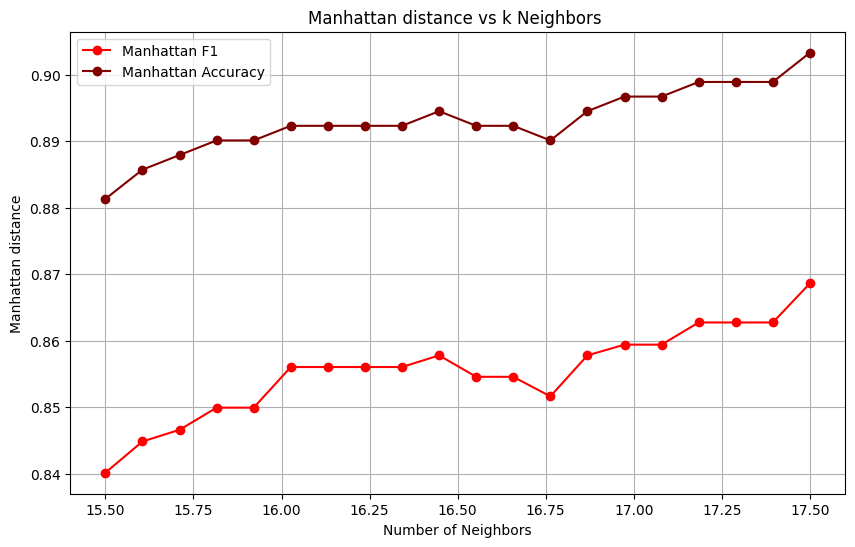

```python
plt.figure(figsize=(10, 6))
plt.plot(r_manhattan, f1_list_manhattan, marker='o', label='Manhattan F1', color='red')
plt.plot(r_manhattan, accuracy_list_manhattan, marker='o', label='Manhattan Accuracy', color='maroon')

plt.title('Manhattan distance vs k Neighbors ')
plt.xlabel('Number of Neighbors')
plt.ylabel('Manhattan distance')
plt.legend()
plt.grid(True)

plt.show()
```

- If r is excessively large a lot more neighbors are taken into account for making predictions. This can cause underfitting. The model will fail to capture important local patterns in the data, resulting in not being able to differentiate between classes all too well.
- A very small value of r implies that very few neighbors are taken into account when making predictions. This can cause overfitting, as the model can become too sensitive to training data's local variations.

### Task 4: Prediction [10 marks]

Finally, use the best value of `r` for both distance metrics and run it on the test dataset. Make sure you do not harcode values of `r` in this part.

Find the confusion matrix, classification accuracy and macro F1 score and print them. You can use Sklearn's evaluation metrics in this part as well.

The confusion matrix must be displayed as a heatmap annotated with the data values. The axes should be properly labelled and the colormap used needs to be shown next to the heatmap.

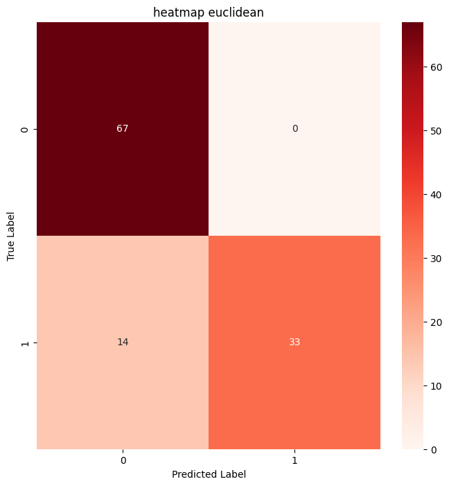

```
Confusion Matrix:
[[67, 0], [14, 33]]
Accuracy: 87.72%
Macro-Average F1 Score: 0.85

[67, 0]
[14, 33]
```

```python
best_r = r_euclidean[np.argmax(accuracy_list_euclidean)]
model = RNN(best_r)
model.fit(normalized_train_x, train_y)

predicted_value = model.predict(normalized_test_x,'euclidean_distance')
make_heat_map(make_confusion_matrix(predicted_value, test_y), 'heatmap euclidean')

confidence, result = evaluate(predicted_value, test_y)
print(result)
for i in range(len(confidence)):
    print(confidence[i])
```

```
Confusion Matrix:
[[67, 0], [13, 34]]
Accuracy: 88.60%
Macro-Average F1 Score: 0.86

[67, 0]
[13, 34]
```

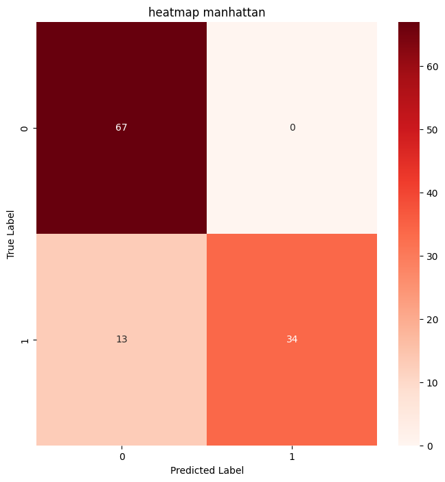

```python
best_r = r_manhattan[np.argmax(accuracy_list_manhattan)]
model = RNN(best_r)
model.fit(normalized_train_x, train_y)
predicted_value = model.predict(normalized_test_x,'manhattan_distance')
confidence, result = evaluate(predicted_value, test_y)
print(result)
for i in range(len(confidence)):
    print(confidence[i])
make_heat_map(make_confusion_matrix(predicted_value, test_y), 'heatmap manhattan')
```

**Why rNN classifier would have been a poor choice for the MNIST dataset. Discuss with respect to curse of dimentionality**